# Analysis of LC/MS/MS data from latently infected Jurkat cells

Hem R. Gurung, Ph.D.

October 10, 2018

Approximately 1 gram cell pellet per cell line was processed for HLA-peptide extraction. Peptides were extracted from the HLA molecules, fractionated by RP-HPLC, and ran on nano-LC MS/MS system (TTOF 5600). Raw data from the mass spectrometer was processed within PEAKS software at 1% FDR to generate peptide hits based on peptide spectrum matches.

A total of **595** peptides were identified in **uninfected Jurkat E6-1** cell line of which **272** were unique peptides.

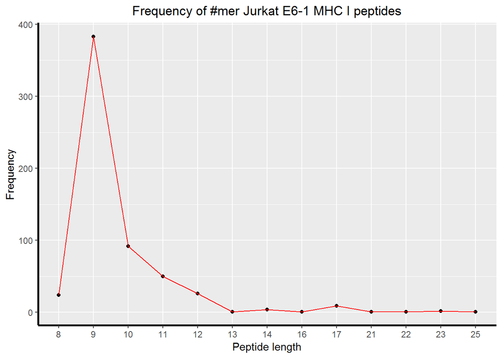

A total of **636** peptides were identified in HIV-1 infected **Jurkat DF731** cell line of which **269** were unique peptides.

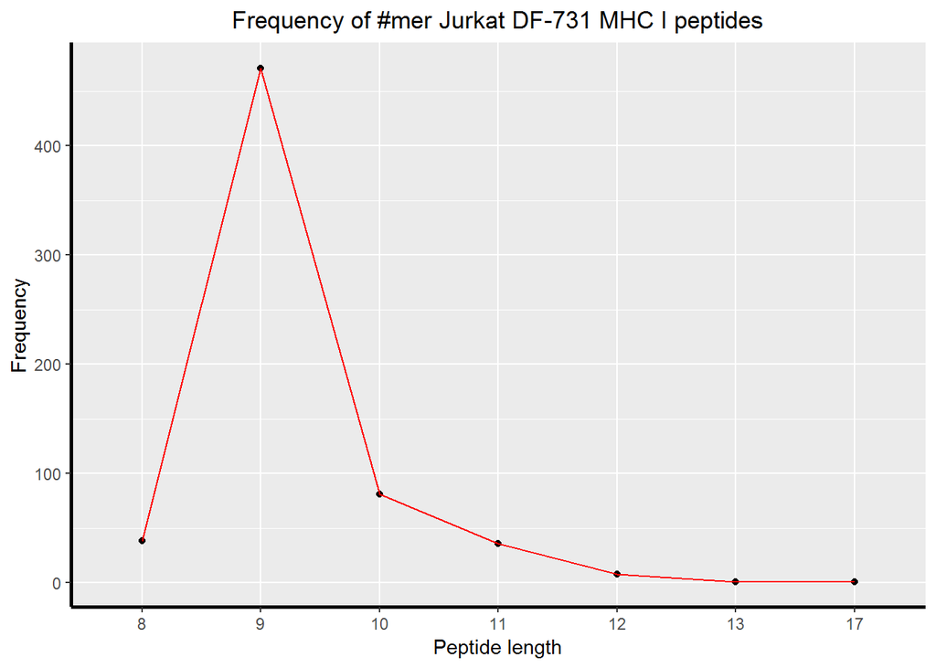

A total of **427** peptides were identified in **HIV-1 infected Jurkat DFRC3** cell line of which **170** were unique peptides.

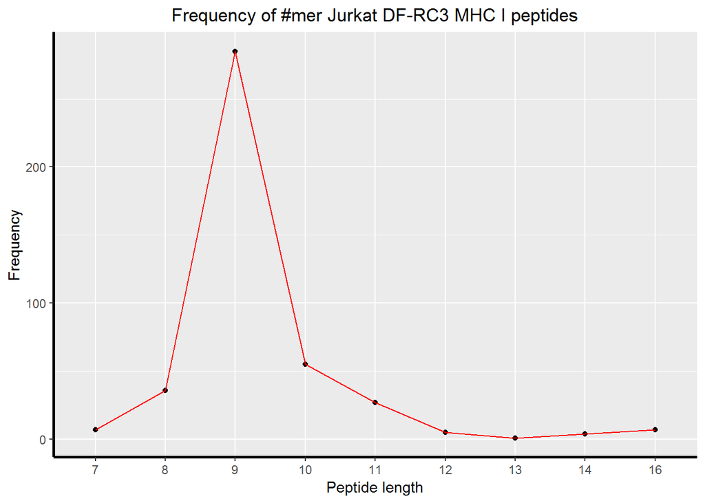

### Comparision between **uninfected Jurkat E6-1** and **HIV-1 infected Jukat DF731** Cell lines

```
## [1] 155
```

Between uninfected Jurkat E6-1 and infected Jurkat DF731, **155** were overlapping peptides.

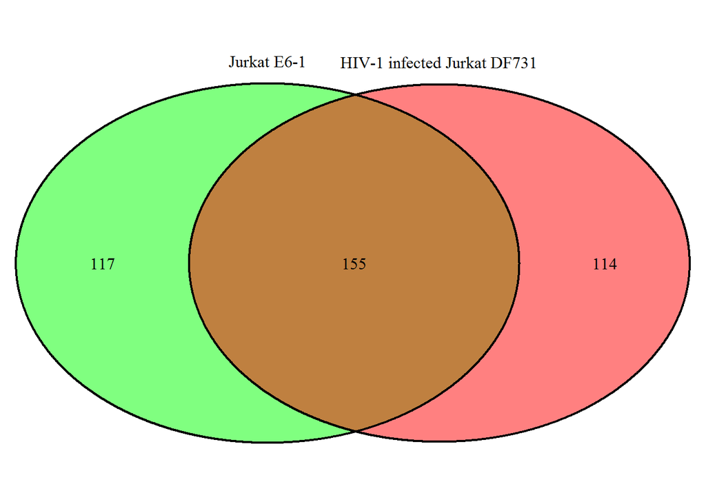

[output not shown]

That means 117 peptides were *unique* to Jurkat E6-1 and 114 peptides were *unique* to HIV-1 infected Jurkat DF731. Performing database match using Anthony Purcell’s Latent HIV-1 database (upregulated genes/proteins) http://hivlatency.erc.monash.edu/searchDBwithExpression?SearchDataset=Mo-HIVvsMockinLatency&SearchEffect=up&SubmitExpression=Submit, 45 peptides in Jurkat E6-1 matched the database whereas 57 peptides in Jurkat DF731 matched the database. Further analysis showed only 2 overlapping genes/proteins between the Jurkat E6-1 and Jurkat DF731 which means 43 peptides were *unique* to Jurkat E6-1 and 55 peptides were *unique* to HIV-1 infected Jurkat DF731.

The reason why the 2 overlapping genes/proteins were observed between the Jurkat E6-1 and Jurkat DF731 was because the two genes/proteins (TNKS2 and TRIP12) were associated with different peptide sequences within each cell line. In other words, different sequences were sampled from the same proteins between the two cell lines.

```
## [1] 45
```

```
## [1] 57
```

```
## [1] 2
```

```
## [1] 43
```

```
## [1] 55
```

The latent HIV-1 associated host peptides that were *unique* to each group are presented in tables below for each cell line.

### Latent HIV-1 associated host peptides in Jurkat E6-1 as compared to Jurkat DF731

|  | Peptide | X.10lgP | Mass | Length | ppm | m.z | RT | Scan | Proteins | Genes |
| --- | --- | --- | --- | --- | --- | --- | --- | --- | --- | --- |
| 2 | GKVKVGVNGFGRIG | 68.44 | 1386.8096 | 14 | 0.9 | 463.2775 | 27.83 | 4014 | Glyceraldehyde-3-phosphate dehydrogenase OS=Homo sapiens OX=9606 GN=GAPDH PE=1 SV=3 | GAPDH |
| 4 | A(+42.01)SSDIQVKELEKRASGQ | 63.72 | 1886.9697 | 17 | -2.5 | 629.9956 | 36.33 | 5537 | Stathmin OS=Homo sapiens OX=9606 GN=STMN1 PE=1 SV=3 | STMN1 |
| 6 | IQRTPKIQVYSRHPAEN | 62.11 | 2036.0916 | 17 | -8.2 | 510.026 | 22.03 | 3288 | Beta-2-microglobulin OS=Homo sapiens OX=9606 GN=B2M PE=1 SV=1 | B2M |
| 8 | S(+42.01)DAAVDTSSEITTK | 56.69 | 1465.6783 | 14 | -4 | 733.8435 | 29.64 | 4463 | Isoform 2 of Prothymosin alpha OS=Homo sapiens OX=9606 GN=PTMA | PTMA |
| 14 | KLFDHAVSKF | 52.69 | 1190.6448 | 10 | 1.4 | 397.8894 | 29.47 | 4399 | Isoform Short of Long-chain-fatty-acid--CoA ligase 4 OS=Homo sapiens OX=9606 GN=ACSL4 | ACSL4 |
| 15 | APRLNSADRPM | 52.3 | 1226.6189 | 11 | -0.5 | 409.88 | 22.62 | 3348 | Isoform 2 of Proline-rich nuclear receptor coactivator 2 OS=Homo sapiens OX=9606 GN=PNRC2 | PNRC2 |
| 17 | KLISEEDLLRK | 50.81 | 1342.782 | 11 | 0 | 448.6013 | 29.69 | 4425 | Myc proto-oncogene protein OS=Homo sapiens OX=9606 GN=MYC PE=1 SV=1 | MYC |
| 24 | Q(-17.03)YDEAVAQF | 48.81 | 1052.4451 | 9 | -4.4 | 527.2275 | 50.37 | 8427 | Isoform 4 of Nuclear autoantigenic sperm protein OS=Homo sapiens OX=9606 GN=NASP | NASP |
| 31 | APRAIPTTGRGSSGVGL | 44.94 | 1595.8743 | 17 | -2.8 | 532.9639 | 27.64 | 3991 | DNA replication licensing factor MCM3 OS=Homo sapiens OX=9606 GN=MCM3 PE=1 SV=3 | MCM3 |
| 36 | VSFPIGIYK | 42.7 | 1022.58 | 9 | 2.3 | 512.2985 | 44.71 | 7239 | Isoform 3 of Leucine-rich repeat-containing protein 20 OS=Homo sapiens OX=9606 GN=LRRC20 | LRRC20 |

[output cut: 33 more lines]

### Latent HIV-1 associated host peptides in HIV-1 infected Jurkat DF731 as compared to Jurkat E6-1

|  | Peptide | X.10lgP | Mass | Length | ppm | m.z | RT | Scan | PROTEINS | Genes |
| --- | --- | --- | --- | --- | --- | --- | --- | --- | --- | --- |
| 3 | IYDFIGEFM(+15.99) | 56.42 | 1149.5052 | 9 | 1.9 | 575.761 | 57.77 | 8559 | Isoform 2 of Transmembrane protein 147 OS=Homo sapiens OX=9606 GN=TMEM147 | TMEM147 |
| 6 | KPSLPFTSL | 48.65 | 988.5593 | 9 | 7.8 | 495.2908 | 44.8 | 6330 | Cytokine receptor common subunit gamma OS=Homo sapiens OX=9606 GN=IL2RG PE=1 SV=1 | IL2RG |
| 7 | SFDETVTHF | 48.28 | 1081.4717 | 9 | 5.7 | 541.7462 | 37.88 | 5382 | DNA topoisomerase 2-binding protein 1 OS=Homo sapiens OX=9606 GN=TOPBP1 PE=1 SV=3 | TOPBP1 |
| 9 | VFDPALNLF | 46.99 | 1034.5437 | 9 | 0.7 | 518.2795 | 61.62 | 8427 | Ubiquitin-protein ligase E3B OS=Homo sapiens OX=9606 GN=UBE3B PE=1 SV=3 | UBE3B |
| 11 | IRSSYIRVL | 44.8 | 1105.6608 | 9 | 0.8 | 369.5612 | 31.34 | 4773 | DNA replication licensing factor MCM5 OS=Homo sapiens OX=9606 GN=MCM5 PE=1 SV=5 | MCM5 |
| 14 | LYDPVISKL | 41.18 | 1046.6012 | 9 | 6.4 | 524.3112 | 42.74 | 6109 | Isoform 3 of Microspherule protein 1 OS=Homo sapiens OX=9606 GN=MCRS1 | MCRS1 |
| 17 | SFDGIIAM(+15.99)M(+15.99) | 40.46 | 1015.4354 | 9 | 6.6 | 508.7283 | 39.85 | 5815 | Transcription elongation factor SPT4 OS=Homo sapiens OX=9606 GN=SUPT4H1 PE=1 SV=1 | SUPT4H1 |
| 19 | IARLPSSTL | 39.56 | 956.5654 | 9 | 5.5 | 479.2926 | 30.97 | 4723 | Isoform 2 of Kinesin-like protein KIF18B OS=Homo sapiens OX=9606 GN=KIF18B | KIF18B |
| 20 | RLPSSTLKR | 38.94 | 1056.6404 | 9 | 0.6 | 353.2209 | 21.81 | 3546 | Isoform 2 of Kinesin-like protein KIF18B OS=Homo sapiens OX=9606 GN=KIF18B | KIF18B |
| 22 | VRPPPGPEL | 38.29 | 960.5392 | 9 | -3.8 | 481.275 | 28.29 | 4248 | Isoform 3 of Helicase SRCAP OS=Homo sapiens OX=9606 GN=SRCAP | SRCAP |

[output cut: 45 more lines]

## Similarly, comparing the **uninfected Jurkat E6-1** and **HIV-1 infected Jukat DFRC3** Cell lines

Between uninfected Jurkat E6-1 and infected Jurkat DFRC3, **101** were overlapping peptides.

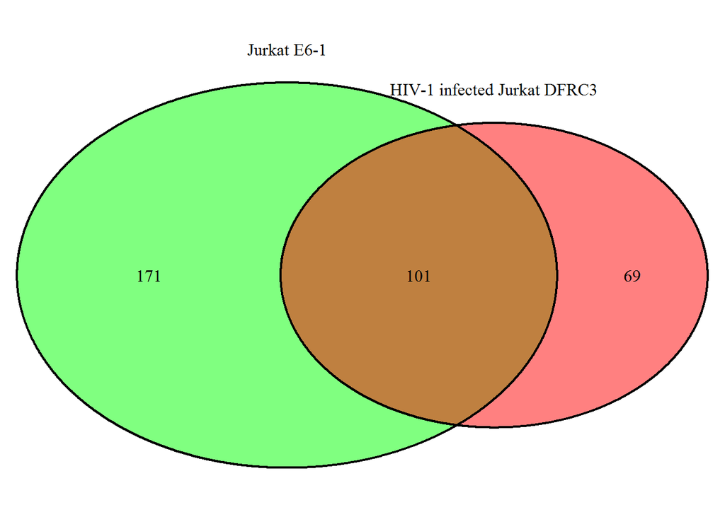

[output not shown]

Again, the reason why the 1 overlapping genes/protein was observed between the Jurkat E6-1 and Jurkat DFRC3 was because the gene/protein (TNKS2) was associated with different peptide sequences within each cell line. In other words, different sequences were sampled from the same protein between the two cell lines.

```
## [1] 66
```

```
## [1] 28
```

```
## [1] 1
```

```
## [1] 65
```

```
## [1] 27
```

The latent HIV-1 associated host peptides that were *unique* to each group are presented in tables below for each cell line.

### Latent HIV-1 associated host peptides in Jurkat E6-1 as compared to Jurkat DFRC3

|  | Peptide | X.10lgP | Mass | Length | ppm | m.z | RT | Scan | Proteins | Genes |
| --- | --- | --- | --- | --- | --- | --- | --- | --- | --- | --- |
| 2 | GKVKVGVNGFGRIG | 68.44 | 1386.8096 | 14 | 0.9 | 463.2775 | 27.83 | 4014 | Glyceraldehyde-3-phosphate dehydrogenase OS=Homo sapiens OX=9606 GN=GAPDH PE=1 SV=3 | GAPDH |
| 4 | A(+42.01)SSDIQVKELEKRASGQ | 63.72 | 1886.9697 | 17 | -2.5 | 629.9956 | 36.33 | 5537 | Stathmin OS=Homo sapiens OX=9606 GN=STMN1 PE=1 SV=3 | STMN1 |
| 6 | IQRTPKIQVYSRHPAEN | 62.11 | 2036.0916 | 17 | -8.2 | 510.026 | 22.03 | 3288 | Beta-2-microglobulin OS=Homo sapiens OX=9606 GN=B2M PE=1 SV=1 | B2M |
| 15 | KLFDHAVSKF | 52.69 | 1190.6448 | 10 | 1.4 | 397.8894 | 29.47 | 4399 | Isoform Short of Long-chain-fatty-acid--CoA ligase 4 OS=Homo sapiens OX=9606 GN=ACSL4 | ACSL4 |
| 16 | SVYYNEATGGK | 52.67 | 1187.5459 | 11 | -4.9 | 594.7773 | 24.8 | 3680 | Tubulin beta chain OS=Homo sapiens OX=9606 GN=TUBB PE=1 SV=2 | TUBB |
| 17 | APRLNSADRPM | 52.3 | 1226.6189 | 11 | -0.5 | 409.88 | 22.62 | 3348 | Isoform 2 of Proline-rich nuclear receptor coactivator 2 OS=Homo sapiens OX=9606 GN=PNRC2 | PNRC2 |
| 20 | KLISEEDLLRK | 50.81 | 1342.782 | 11 | 0 | 448.6013 | 29.69 | 4425 | Myc proto-oncogene protein OS=Homo sapiens OX=9606 GN=MYC PE=1 SV=1 | MYC |
| 28 | Q(-17.03)YDEAVAQF | 48.81 | 1052.4451 | 9 | -4.4 | 527.2275 | 50.37 | 8427 | Isoform 4 of Nuclear autoantigenic sperm protein OS=Homo sapiens OX=9606 GN=NASP | NASP |
| 29 | VLAPEGSVPNK | 48.68 | 1109.608 | 11 | -9.9 | 555.8058 | 24.86 | 3684 | Isoform B of Ras GTPase-activating protein-binding protein 2 OS=Homo sapiens OX=9606 GN=G3BP2 | G3BP2 |
| 36 | LPRAVGTQTL | 45.91 | 1054.6135 | 10 | -7.4 | 528.3101 | 29.78 | 4370 | Isoform 1A of Sorting nexin-1 OS=Homo sapiens OX=9606 GN=SNX1 | SNX1 |

[output cut: 55 more lines]

### Latent HIV-1 associated host peptides in HIV-1 infected Jurkat DFRC3 as compared to Jurkat E6-1

|  | Peptide | X.10lgP | Mass | Length | ppm | m.z | RT | Scan | Proteins | Genes |
| --- | --- | --- | --- | --- | --- | --- | --- | --- | --- | --- |
| 7 | IVAGSLITK | 46.51 | 900.5644 | 9 | 14.3 | 451.2959 | 28.13 | 4242 | Isoform 2 of Pre-mRNA-processing factor 40 homolog A OS=Homo sapiens OX=9606 GN=PRPF40A | PRPF40A |
| 8 | IRSSYIRVL | 44.85 | 1105.6608 | 9 | 8.8 | 369.5641 | 31.49 | 4776 | DNA replication licensing factor MCM5 OS=Homo sapiens OX=9606 GN=MCM5 PE=1 SV=5 | MCM5 |
| 13 | VRPPPGPEL | 39.37 | 960.5392 | 9 | 3.2 | 481.2784 | 28.48 | 4287 | Isoform 3 of Helicase SRCAP OS=Homo sapiens OX=9606 GN=SRCAP | SRCAP |
| 14 | IYDFIGEFM(+15.99) | 38.48 | 1149.5052 | 9 | 4.5 | 575.7625 | 57.7 | 7612 | Isoform 2 of Transmembrane protein 147 OS=Homo sapiens OX=9606 GN=TMEM147 | TMEM147 |
| 15 | AYRQGHFTY | 37.4 | 1141.5305 | 9 | 6.3 | 381.5198 | 24.95 | 3851 | Structural maintenance of chromosomes protein 6 OS=Homo sapiens OX=9606 GN=SMC6 PE=1 SV=2 | SMC6 |
| 16 | IARLPSSTL | 37.39 | 956.5654 | 9 | 5.8 | 479.2928 | 31.34 | 4637 | Isoform 2 of Kinesin-like protein KIF18B OS=Homo sapiens OX=9606 GN=KIF18B | KIF18B |
| 17 | IYDKFIAQL | 36.99 | 1109.6121 | 9 | 7.9 | 555.8177 | 46.34 | 6625 | Isoform 4 of Polyamine-modulated factor 1 OS=Homo sapiens OX=9606 GN=PMF1 | PMF1 |
| 23 | VPEEARPAL | 33.4 | 980.5291 | 9 | 1.2 | 491.2724 | 26.16 | 3948 | DDB1- and CUL4-associated factor 15 OS=Homo sapiens OX=9606 GN=DCAF15 PE=1 SV=1 | DCAF15 |
| 24 | KPSLPFTSL | 32.55 | 988.5593 | 9 | 7.3 | 495.2906 | 44.96 | 6246 | Cytokine receptor common subunit gamma OS=Homo sapiens OX=9606 GN=IL2RG PE=1 SV=1 | IL2RG |
| 25 | VLYNGFTGR | 32.26 | 1025.5294 | 9 | 7.5 | 513.7758 | 31.34 | 4488 | DNA-directed RNA polymerase II subunit RPB2 OS=Homo sapiens OX=9606 GN=POLR2B PE=1 SV=1 | POLR2B |

[output cut: 17 more lines]

## How many genes overlap between the Jurkat DF731 and Jurkat DFRC3?

```
## [1] 18
```

```
## [1] 18
```

#### The table below contains the final list of 18 unique peptides/genes/proteins that overlapped HIV-1 infected Jurkats DF731 and Jurkat DFRC3

|  | Peptide | X.10lgP | Mass | Length | ppm | m.z | RT | Scan | PROTEINS | Genes |
| --- | --- | --- | --- | --- | --- | --- | --- | --- | --- | --- |
| 1 | IYDFIGEFM(+15.99) | 56.42 | 1149.5052 | 9 | 1.9 | 575.761 | 57.77 | 8559 | Isoform 2 of Transmembrane protein 147 OS=Homo sapiens OX=9606 GN=TMEM147 | TMEM147 |
| 2 | KPSLPFTSL | 48.65 | 988.5593 | 9 | 7.8 | 495.2908 | 44.8 | 6330 | Cytokine receptor common subunit gamma OS=Homo sapiens OX=9606 GN=IL2RG PE=1 SV=1 | IL2RG |
| 3 | SFDETVTHF | 48.28 | 1081.4717 | 9 | 5.7 | 541.7462 | 37.88 | 5382 | DNA topoisomerase 2-binding protein 1 OS=Homo sapiens OX=9606 GN=TOPBP1 PE=1 SV=3 | TOPBP1 |
| 5 | IRSSYIRVL | 44.8 | 1105.6608 | 9 | 0.8 | 369.5612 | 31.34 | 4773 | DNA replication licensing factor MCM5 OS=Homo sapiens OX=9606 GN=MCM5 PE=1 SV=5 | MCM5 |
| 8 | IARLPSSTL | 39.56 | 956.5654 | 9 | 5.5 | 479.2926 | 30.97 | 4723 | Isoform 2 of Kinesin-like protein KIF18B OS=Homo sapiens OX=9606 GN=KIF18B | KIF18B |
| 10 | VRPPPGPEL | 38.29 | 960.5392 | 9 | -3.8 | 481.275 | 28.29 | 4248 | Isoform 3 of Helicase SRCAP OS=Homo sapiens OX=9606 GN=SRCAP | SRCAP |
| 12 | AIYKTPPGIQK | 36.86 | 1214.7023 | 11 | 3.1 | 405.9093 | 23.43 | 3576 | Isoform 3 of BCL-6 corepressor OS=Homo sapiens OX=9606 GN=BCOR | BCOR |
| 13 | IYDKFIAQL | 36.75 | 1109.6121 | 9 | 11.9 | 555.8199 | 46.6 | 6708 | Isoform 4 of Polyamine-modulated factor 1 OS=Homo sapiens OX=9606 GN=PMF1 | PMF1 |
| 17 | VM(+15.99)APRTLLL | 35.49 | 1028.6052 | 9 | 8 | 515.314 | 40.5 | 5857 | HLA class I histocompatibility antigen A-33 alpha chain OS=Homo sapiens OX=9606 GN=HLA-A PE=1 SV=3 | HLA-A |
| 20 | APSGGRLLSA | 33.27 | 927.5137 | 10 | 13.7 | 464.7705 | 25.74 | 3934 | Isoform 2 of Aladin OS=Homo sapiens OX=9606 GN=AAAS | AAAS |

[output cut: 8 more lines]